# TRAP: exposure prediction with mobile monitoring data

Si Cheng

2021-01-02

## Notes/to-do from previous meetings

- Further fine-tune the parameters in spatial RF
- Combine TPRS with UK-PLS and see how it performs
- Visualize variable performance (loadings for PLS and accuracy lost from permutation for spatRF)

## Summary

- Fine-tuning leads to better performance of spatRF (now very close to UK-PLS)
- The performance of PLS with TPRS basis is worse than spatRF with TPRS covariance
- Visualization of variable importance in next section

Prediction models were built for two pollutants – ultrafine particles (UFP) and black carbon (BC), and we consider two versions of annual averages for each of them – the simple unweighted annual average and the adjusted one (regression estimates adjusted for season, time-of-week- and time-of-day). Models were based on the log-transformed annual averages.

5-fold CV was conducted to compare the accuracy of UK-PLS (exponential and TPRS covariance) and two spatial random forest (pseudo-likelihood and nonparametric) models. Accuracy of each model (along with the original UK-PLS model done by the group) was summarized below by $R^2$.

The following parameters of spatial random forest were selected by random search within a given range:

- Number of covariates to sample for each tree
- Minimum leaf size (and in turn, the maximum number of leaves to use)
- Number of observations to use in each tree

|  | Original | UK PLS (Exp) | UK PLS (TPRS) | SpatRF (PL) | SpatRF (NP) |
| --- | --- | --- | --- | --- | --- |
| UFP adjusted | 0.77 | 0.81 | 0.70 | 0.80 | 0.78 |
| UFP unweighted | 0.78 | 0.81 | 0.70 | 0.79 | 0.79 |
| BC adjusted | 0.71 | 0.70 | 0.58 | 0.68 | 0.68 |
| BC unweighted | 0.71 | 0.70 | 0.58 | 0.70 | 0.68 |

The accuracy of UK-PLS was close to the original results.

The figure below shows a comparison of prediction error of different models. The first column are the observed pollutant concentrations (log scale), and the remaining 3 columns show CV errors.

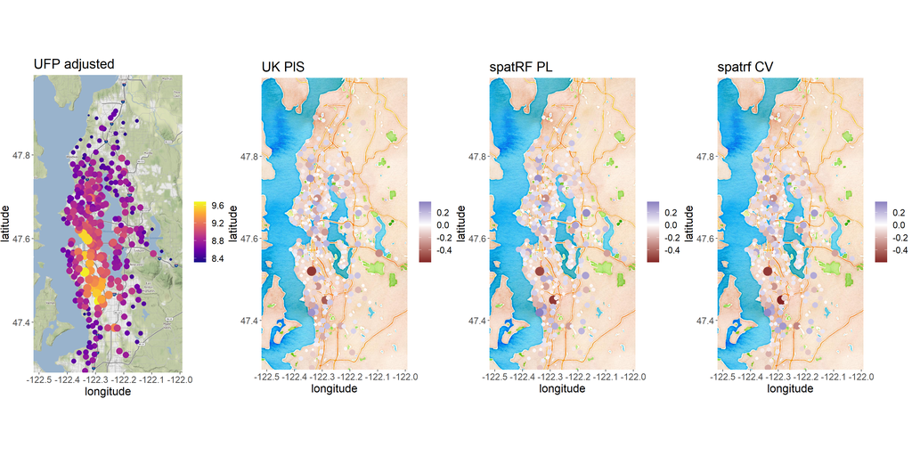

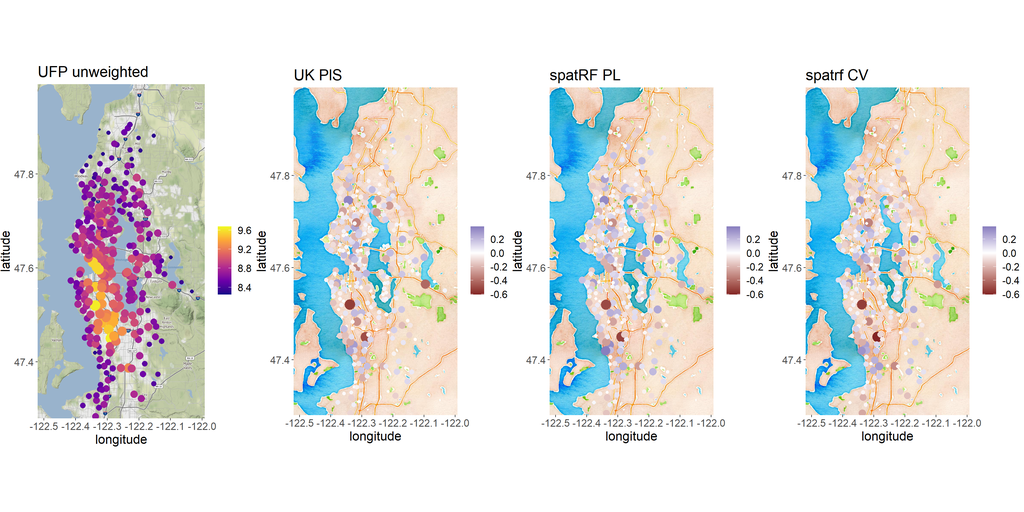

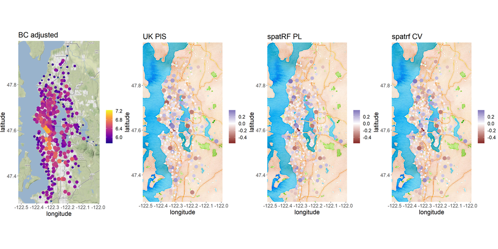

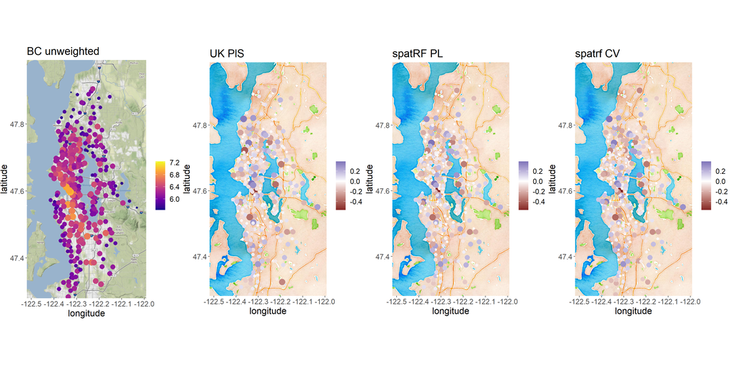

## Variable importance

The plots below visualize the PLS loadings (for UK-PLS) and the loss in prediction accuracy from permuting the values of each predictor (for spatRF). We see that UK-PLS and spatRF identify similar sets of ``important’’ predictors:

|  | UK PLS | spatRF |
| --- | --- | --- |
| UFP | NDVI (-), distance to port and rail yard (-), highly developed land use (+), imperviousness (+), population density (+), major road length (+), number of intersections within a buffer (+) | major road length, distance to major road, truck length (tl_s?), highly developed land use, distance to truck, distance to major road intersection |
| BC | similar to UFP | tl_s, distance to truck and railroad, elevation |

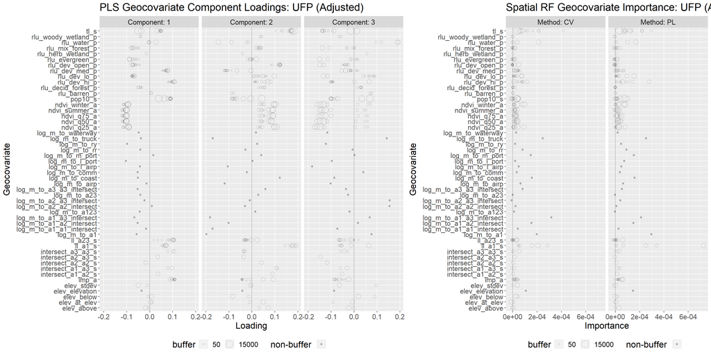

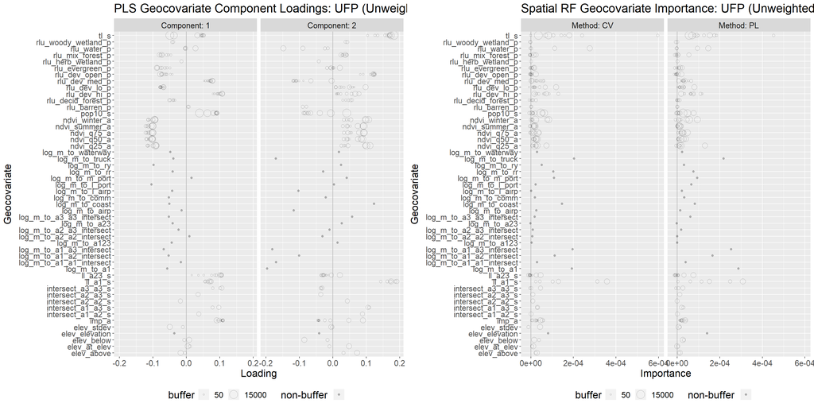

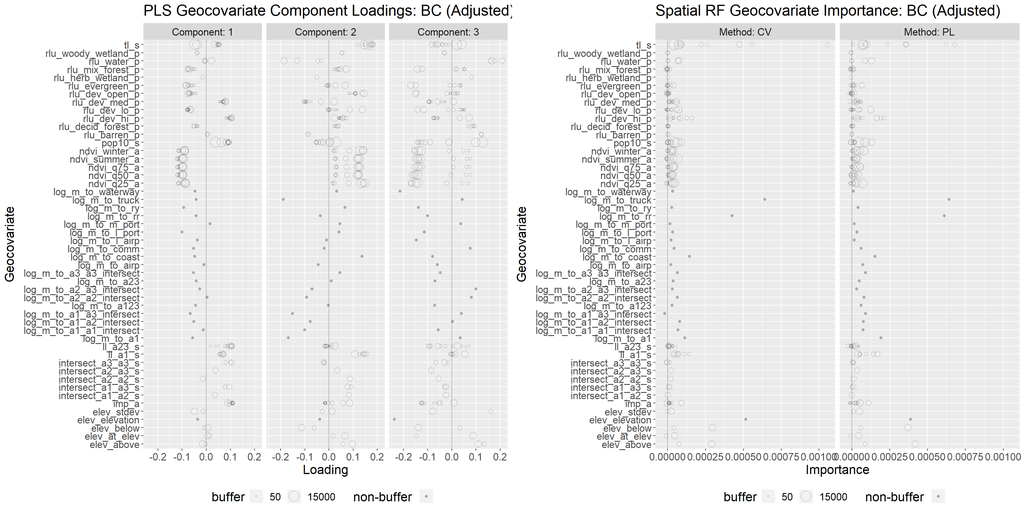

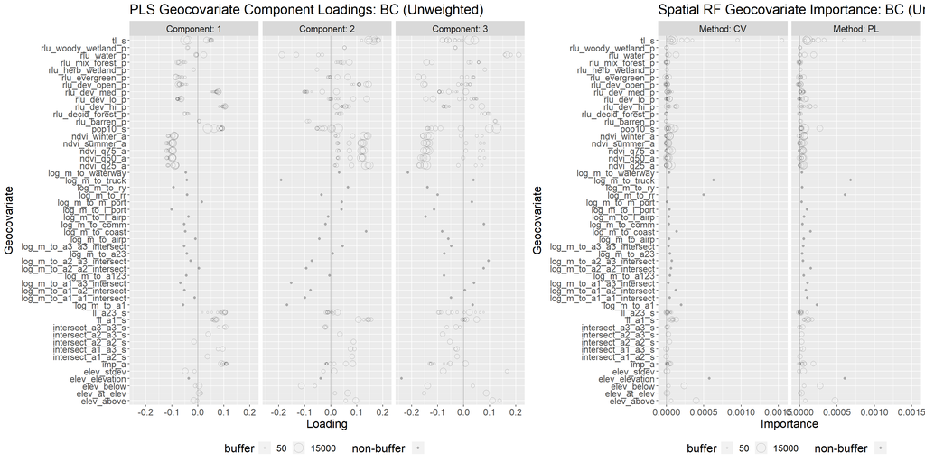